# Installation

## Downloading financial information for ONE company

All you need to download financial data with `GetITRData` are the official names of companies, which can be found with `gitrd.search.company`, the desired starting and ending dates and the type of financial information (individual or consolidated). Let’s try it for PETROBRAS:

```r
name.companies <- 'PETROBRAS'
first.date <- '2005-01-01'
last.date  <- '2006-01-01'
type.statements <- 'individual'

df.reports <- gitrd.GetITRData(name.companies = name.companies,
                               first.date = first.date,
                               last.date = last.date,
                               type.info = type.statements)
```

```
##
## Reading info file from github
## Found 24012 lines for 603 companies  [Actives =  457  Inactives =  146 ]
## Last file update:  2017-09-19
##
## Type of financial statements: individual
## First Date: 2005-01-01
## Laste Date: 2006-01-01
## Inflation index: none
##
##
##
## WARNING: For quarters before 2009, the cash flow statements are not available
##
## Starting processing stage:
## PETROBRAS
##  Available quarters: 2005-09-30  2005-06-30  2005-03-31
##
##
## Processing PETROBRAS, Quarter = 2005-09-30   Downloading | Reading file
## Processing PETROBRAS, Quarter = 2005-06-30   Downloading | Reading file
## Processing PETROBRAS, Quarter = 2005-03-31   Downloading | Reading file
```

The resulting object is a `tibble`, a data.frame type of object that allows for list columns. Let’s have a look in its content:

```r
str(df.reports)
```

```
## Classes 'tbl_df', 'tbl' and 'data.frame':    1 obs. of  10 variables:
##  $ company.name: chr "PETROBRAS"
##  $ company.code: int 9512
##  $ type.info   : chr "individual"
##  $ min.date    : Date, format: "2005-03-31"
##  $ max.date    : Date, format: "2005-09-30"
##  $ n.quarters  : int 3
##  $ assets      :List of 1
##   ..$ :Classes 'tbl_df', 'tbl' and 'data.frame': 191 obs. of  5 variables:
##   .. ..$ acc.number  : chr  "1" "1.01" "1.01.01" "1.01.01.01" ...
##   .. ..$ acc.desc    : chr  "Ativo Total" "Ativo Circulante" "Disponibilidades" "Caixa e Bancos" ...
##   .. ..$ acc.value   : int  147026464 41052623 15146496 1498194 13648302 9450575 3488650 4955111 1090180 -83366 ...
##   .. ..$ ref.date    : Date, format: "2005-09-30" ...
##   .. ..$ company.name: chr  "PETROBRAS" "PETROBRAS" "PETROBRAS" "PETROBRAS" ...
##  $ liabilities :List of 1
##   ..$ :Classes 'tbl_df', 'tbl' and 'data.frame': 160 obs. of  5 variables:
##   .. ..$ acc.number  : chr  "2" "2.01" "2.01.01" "2.01.01.01" ...
##   .. ..$ acc.desc    : chr  "Passivo Total" "Passivo Circulante" "Empréstimos e Financiamentos" "Financiamentos" ...
##   .. ..$ acc.value   : int  147026464 44603494 1154258 1039841 114417 0 5205735 7429086 1156875 935603 ...
##   .. ..$ ref.date    : Date, format: "2005-09-30" ...
##   .. ..$ company.name: chr  "PETROBRAS" "PETROBRAS" "PETROBRAS" "PETROBRAS" ...
##  $ income      :List of 1
##   ..$ :Classes 'tbl_df', 'tbl' and 'data.frame': 100 obs. of  5 variables:
##   .. ..$ acc.number  : chr  "3.01" "3.02" "3.03" "3.04" ...
##   .. ..$ acc.desc    : chr  "Receita Bruta de Vendas e/ou Serviços" "Deduções da Receita Bruta" "Receita Líquida de Vendas e/ou Serviços" "Custo de Bens e/ou Serviços Vendidos" ...
##   .. ..$ acc.value   : int  37870949 -9778549 28092400 -15030559 13061841 -4270217 -1221668 -895230 -899 -894331 ...
##   .. ..$ ref.date    : Date, format: "2005-09-30" ...
##   .. ..$ company.name: chr  "PETROBRAS" "PETROBRAS" "PETROBRAS" "PETROBRAS" ...
##  $ df.cashflow :List of 1
##   ..$ :'data.frame': 0 obs. of  5 variables:
##   .. ..$ acc.desc    : Named list()
##   .. ..$ acc.value   : logi
##   .. ..$ acc.number  : chr
##   .. ..$ company.name: chr
##   .. ..$ ref.date    :Class 'Date'  num(0)
##   .. ..- attr(*, "na.action")=Class 'omit'  Named int [1:3] 1 2 3
##   .. .. .. ..- attr(*, "names")= chr [1:3] "1" "2" "3"
```

Object `df.reports` only has one row since we only asked for data of one company. The number of rows increases with the number of companies, as we will soon learn with the next example. All financial statements for the different quarters are available within `df.reports`. For example, the income statements for all desired quarters of PETROBRAS are:

```r
df.income.long <- df.reports$income[[1]]

str(df.income.long)
```

```
## Classes 'tbl_df', 'tbl' and 'data.frame':    100 obs. of  5 variables:
##  $ acc.number  : chr  "3.01" "3.02" "3.03" "3.04" ...
##  $ acc.desc    : chr  "Receita Bruta de Vendas e/ou Serviços" "Deduções da Receita Bruta" "Receita Líquida de Vendas e/ou Serviços" "Custo de Bens e/ou Serviços Vendidos" ...
##  $ acc.value   : int  37870949 -9778549 28092400 -15030559 13061841 -4270217 -1221668 -895230 -899 -894331 ...
##  $ ref.date    : Date, format: "2005-09-30" "2005-09-30" ...
##  $ company.name: chr  "PETROBRAS" "PETROBRAS" "PETROBRAS" "PETROBRAS" ...
```

The resulting dataframe is in the long format, ready for processing. In the long format, financial statements of different quarters are stacked. In the wide format, we have the quarters as dates. If you want the wide format, which I believe is most common in financial analysis, you can use function `gitrd.convert.to.wide`. See an example next:

```r
df.income.wide <- gitrd.convert.to.wide(df.income.long)

knitr::kable(df.income.wide )
```

| acc.number | acc.desc | company.name | 2005-03-31 | 2005-06-30 | 2005-09-30 |
| --- | --- | --- | --- | --- | --- |
| 3.01 | Receita Bruta de Vendas e/ou Serviços | PETROBRAS | 31355183 | 35425584 | 37870949 |
| 3.02 | Deduções da Receita Bruta | PETROBRAS | -8788723 | -9321322 | -9778549 |
| 3.03 | Receita Líquida de Vendas e/ou Serviços | PETROBRAS | 22566460 | 26104262 | 28092400 |
| 3.04 | Custo de Bens e/ou Serviços Vendidos | PETROBRAS | -12052044 | -14530594 | -15030559 |
| 3.05 | Resultado Bruto | PETROBRAS | 10514416 | 11573668 | 13061841 |
| 3.06 | Despesas/Receitas Operacionais | PETROBRAS | -2869703 | -5249799 | -4270217 |
| 3.06.01 | Com Vendas | PETROBRAS | -858170 | -820899 | -1221668 |
| 3.06.02 | Gerais e Administrativas | PETROBRAS | -768830 | -880185 | -895230 |
| 3.06.02.01 | Honor.Diretoria e Cons. Administração | PETROBRAS | -984 | -886 | -899 |
| 3.06.02.02 | De Administração | PETROBRAS | -767846 | -879299 | -894331 |
| 3.06.03 | Financeiras | PETROBRAS | -53787 | -480281 | -282706 |
| 3.06.03.01 | Receitas Financeiras | PETROBRAS | 525452 | 106753 | 272290 |
| 3.06.03.02 | Despesas Financeiras | PETROBRAS | -579239 | -587034 | -554996 |
| 3.06.04 | Outras Receitas Operacionais | PETROBRAS | 0 | 0 | 0 |
| 3.06.05 | Outras Despesas Operacionais | PETROBRAS | -2104923 | -3155693 | -1956858 |
| 3.06.05.01 | Custos Explot.p/Extração Petróleo/Gás | PETROBRAS | -107010 | -101527 | -334116 |
| 3.06.05.02 | Custo c/ Pesq. Desenv. Tecnológico | PETROBRAS | -192741 | -221813 | -247456 |
| 3.06.05.03 | Tributárias | PETROBRAS | -185581 | -290086 | -114519 |
| 3.06.05.04 | Variações Monetárias e Cambiais Líquidas | PETROBRAS | -117821 | -921626 | -401757 |
| 3.06.05.05 | Outras Despesas/Receitas Oper. Liquidas | PETROBRAS | -1501770 | -1620641 | -859010 |
| 3.06.06 | Resultado da Equivalência Patrimonial | PETROBRAS | 916007 | 87259 | 86245 |
| 3.07 | Resultado Operacional | PETROBRAS | 7644713 | 6323869 | 8791624 |
| 3.08 | Resultado Não Operacional | PETROBRAS | -151498 | -64670 | 1064 |
| 3.08.01 | Receitas | PETROBRAS | 1256 | 8805 | 450552 |
| 3.08.02 | Despesas | PETROBRAS | -152754 | -73475 | -449488 |
| 3.09 | Resultado Antes Tributação/Participações | PETROBRAS | 7493215 | 6259199 | 8792688 |
| 3.10 | Provisão para IR e Contribuição Social | PETROBRAS | -1847762 | -1151342 | -3002751 |
| 3.11 | IR Diferido | PETROBRAS | -538132 | -408725 | -111709 |
| 3.12 | Participações/Contribuições Estatutárias | PETROBRAS | 0 | 0 | 0 |
| 3.12.01 | Participações | PETROBRAS | 0 | 0 | 0 |
| 3.12.01.01 | Partic. de Empregados e administradores | PETROBRAS | 0 | NA | NA |
| 3.12.02 | Contribuições | PETROBRAS | 0 | 0 | 0 |
| 3.13 | Reversão dos Juros sobre Capital Próprio | PETROBRAS | 0 | 0 | 0 |
| 3.15 | Lucro/Prejuízo do Período | PETROBRAS | 5107321 | 4699132 | 5678228 |

## Downloading financial information for SEVERAL companies

If you are doing serious research, it is likely that you need financial statements for more than one company. Package `GetITRData` is specially designed for handling large scale download of data. Let’s build a case with 5 randomly selected companies:

```r
set.seed(5)
my.companies <- sample(unique(df.info$name.company), 5)

first.date <- '2005-01-01'
last.date  <- '2006-01-01'
type.statements <- 'individual'

df.reports <- gitrd.GetITRData(name.companies = my.companies,
                                  first.date = first.date,
                                  last.date = last.date,
                                  type.info = type.statements)
```

```
##
## Reading info file from github
## Found 24012 lines for 603 companies  [Actives =  457  Inactives =  146 ]
## Last file update:  2017-09-19
##
## Type of financial statements: individual individual  individual  individual  individual
## First Date: 2005-01-01
## Laste Date: 2006-01-01
## Inflation index: none
##
##
##
## WARNING: Cant find available dates for BV LEASING
## WARNING: For quarters before 2009, the cash flow statements are not available
##
## Starting processing stage:
## BANESTES S/A
##  Available quarters: 2005-09-30  2005-06-30  2005-03-31
## CIA. IGUAÇU DE CAFÉ SOLÚVEL
##  Available quarters: 2005-09-30  2005-06-30  2005-03-31
## MUNDIAL
##  Available quarters: 2005-09-30  2005-06-30  2005-03-31
## TELEMAR PARTICIPAÇÔES S.A
##  Available quarters: 2005-09-30  2005-06-30  2005-03-31
##
##
## Processing BANESTES S/A, Quarter = 2005-09-30    Downloading | Reading file
## Processing BANESTES S/A, Quarter = 2005-06-30    Downloading | Reading file
## Processing BANESTES S/A, Quarter = 2005-03-31    Downloading | Reading file
```

```
##
## Processing CIA. IGUAÇU DE CAFÉ SOLÚVEL, Quarter = 2005-09-30 Downloading | Reading file
## Processing CIA. IGUAÇU DE CAFÉ SOLÚVEL, Quarter = 2005-06-30 Downloading | Reading file
## Processing CIA. IGUAÇU DE CAFÉ SOLÚVEL, Quarter = 2005-03-31 Downloading | Reading file
```

```
##
## Processing MUNDIAL, Quarter = 2005-09-30 Downloading | Reading file
## Processing MUNDIAL, Quarter = 2005-06-30 Downloading | Reading file
## Processing MUNDIAL, Quarter = 2005-03-31 Downloading | Reading file
```

```
##
## Processing TELEMAR PARTICIPAÇÔES S.A, Quarter = 2005-09-30   Downloading | Reading file
## Processing TELEMAR PARTICIPAÇÔES S.A, Quarter = 2005-06-30   Downloading | Reading file
## Processing TELEMAR PARTICIPAÇÔES S.A, Quarter = 2005-03-31   Downloading | Reading file
```

And now we can check the resulting `tibble`:

```r
head(df.reports )
```

```
## # A tibble: 4 x 10
##                  company.name company.code  type.info   min.date
##                         <chr>        <int>      <chr>     <date>
## 1                BANESTES S/A         1155 individual 2005-03-31
## 2 CIA. IGUAÇU DE CAFÉ SOLÚVEL         3336 individual 2005-03-31
## 3                     MUNDIAL         5312 individual 2005-03-31
## 4   TELEMAR PARTICIPAÇÔES S.A        18678 individual 2005-03-31
## # ... with 6 more variables: max.date <date>, n.quarters <int>,
## #   assets <list>, liabilities <list>, income <list>, df.cashflow <list>
```

Every row of `df.reports` will provide information for one company. Metadata about the corresponding dataframes such as min/max dates is available in the first columns. Keeping a tabular structure facilitates the organization and future processing of all financial data. We can use tibble `df.reports` for creating other dataframes in the long format containing data for all companies. See next, where we create dataframes with the assets and liabilities of all companies:

```r
df.assets <- do.call(what = rbind, args = df.reports$assets)
df.liabilities <- do.call(what = rbind, args = df.reports$liabilities)

df.assets.liabilities <- rbind(df.assets, df.liabilities)
```

As an example, let’s use the resulting dataframe for calculating and analyzing a simple liquidity index of a company, the total of current (liquid) assets (*Ativo circulante*) divided by the total of current short term liabilities (*Passivo Circulante*), over time.

```r
library(dplyr)
my.tab <- df.assets.liabilities %>%
  group_by(company.name, ref.date) %>%
  summarise(Liq.Index = acc.value[acc.number == '1.01']/ acc.value[acc.number == '2.01'])

my.tab
```

```
## # A tibble: 12 x 3
## # Groups:   company.name [?]
##                   company.name   ref.date Liq.Index
##                          <chr>     <date>     <dbl>
##  1                BANESTES S/A 2005-03-31 0.7985816
##  2                BANESTES S/A 2005-06-30 0.8393188
##  3                BANESTES S/A 2005-09-30 0.9151590
##  4 CIA. IGUAÇU DE CAFÉ SOLÚVEL 2005-03-31 2.3459918
##  5 CIA. IGUAÇU DE CAFÉ SOLÚVEL 2005-06-30 2.7291873
##  6 CIA. IGUAÇU DE CAFÉ SOLÚVEL 2005-09-30 2.1644541
##  7                     MUNDIAL 2005-03-31 0.7903105
##  8                     MUNDIAL 2005-06-30 0.8555824
##  9                     MUNDIAL 2005-09-30 0.9052814
## 10   TELEMAR PARTICIPAÇÔES S.A 2005-03-31 1.5650393
## 11   TELEMAR PARTICIPAÇÔES S.A 2005-06-30 0.9419386
## 12   TELEMAR PARTICIPAÇÔES S.A 2005-09-30 1.3275712
```

Now we can visualize the information using `ggplot2`:

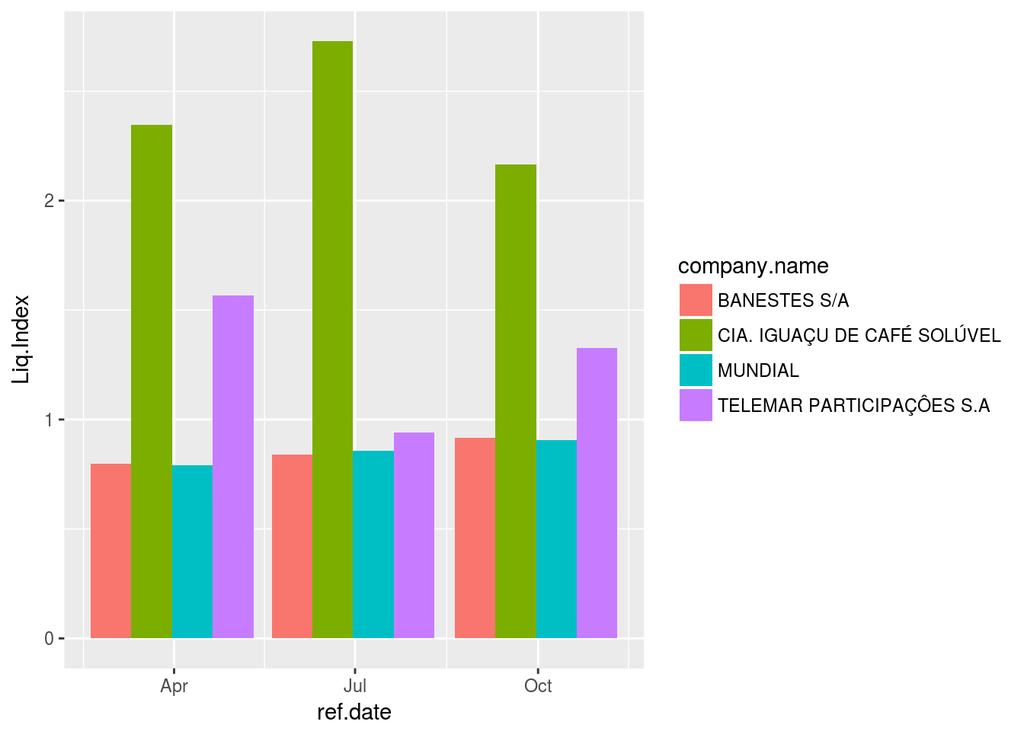

```r
library(ggplot2)

p <- ggplot(my.tab, aes(x = ref.date, y = Liq.Index, fill = company.name)) +
  geom_col(position = 'dodge' )
print(p)
```

As we can see, CIA IGUACU is the company with highest liquidity, being able to pay its short term debt with the current assets in all quarters. We can certainly do a lot more interesting studies based on this dataset.

## Exporting financial data

The package includes function `gitrd.export.ITR.data` for exporting the financial data to an Excel file. Users can choose between the long and wide format. See next:

```r
my.basename <- 'MyExcelData'
my.format <- 'xlsx' # only supported so far
gitrd.export.ITR.data(data.in = df.reports,
                      base.file.name = my.basename,
                      type.export = my.format,
                      format.data = 'long')
```

The resulting Excel file contains all data available in `df.reports`.